# Multivariate Analysis Project

Gavin Connolly

22/03/2022

The initial columns in the dataset contain details (i.e. covariates) of the cows which produced the milk samples and the protein and technological traits of the milk samples measured in the laboratory. The data in the final 531 columns are the MIR spectra, with the first row of these columns detailing the wavenumber (measured in cm−1). The spectral values in the dataset are the absorbance values (the log10 of the reciprocal of the transmittance value). The water region has been removed.

## Question 1

Load the data set into R. Use the set.seed function in R to set the seed to your student number. Randomly generate a number between 1 and n (where n is the number of rows in the dataset), and delete that observation/row from the dataset. Ensure that you include the code used in this step in the R code associated with your assignment.

```r
data = read.csv("Milk_MIR_Traits_data.csv")
# Set seed to student number
set.seed(18308483)
n = nrow(data)
#generate random number between 1 & n
rdm_number = sample(1:n, 1)
data <- data[-rdm_number,] # delete row number from dataset
n = n-1
```

## Question 2

Visualise the spectra and the protein trait $\alpha_{s1}$-casein using (separate) suitable plots. Comment on the plots. Remove any observations with $\alpha_{s1}$-casein outside of 3 standard deviations from the mean of the trait.

#### Visualisation of Spectra:

There is too much data associated with the spectra to simply plot each of the values for each observation, so instead we examine the means & standard deviations of the variable instead.

```r
ncol(data)
```

```
## [1] 582
```

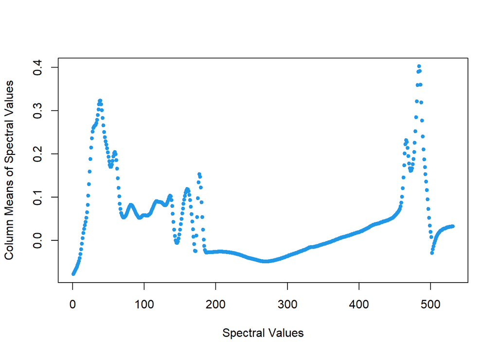

```r
spectra <- data[,52:582] # last 531 columns correspond to spectral readings

# plot column means of spectral values to get idea of their distribution
plot(colMeans(spectra), pch = 20, col = 4,
    xlab = 'Spectral Values', ylab = "Column Means of Spectral Values")
```

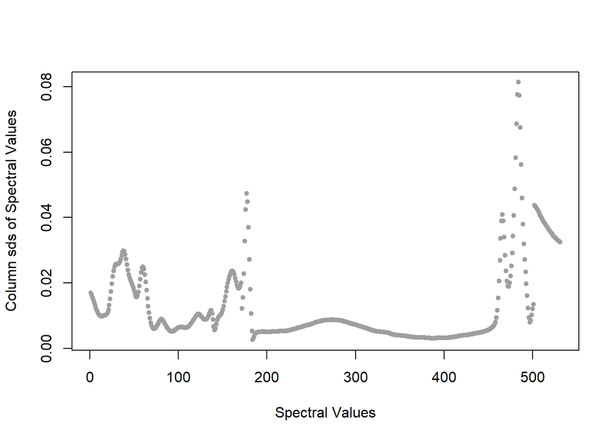

```r
# plot column standard deviations of spectral values
plot(apply(spectra, 2, sd),  pch = 20, col = 8,
     xlab = 'Spectral Values', ylab = "Column sds of Spectral Values")
```

We see from the above plots that there appears to be a pattern within the spectral values, in that variables with higher means also seem to have a higher standard deviation, while variables with a lower mean have a lower standard deviation. It is also appears that there roughly 3 periods of relatively high variability/mean, interspersed between 2 periods of relatively low variability/mean.

#### Visualisation of $\alpha_{s1}$-Casein:

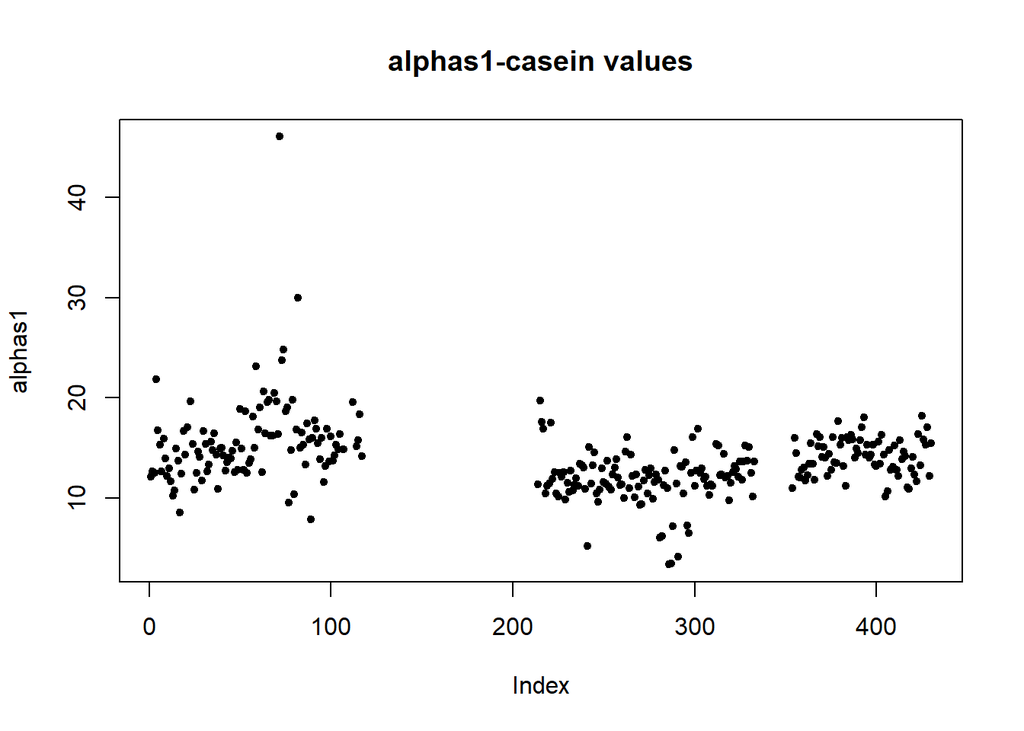

```r
# 9th column corresponds to measurements of alphas1-casein
alphas1 <- data[,9]
plot(alphas1, pch = 20, main = 'alphas1-casein values') # large portion of missing data apparent in plot
```

```r
# remove observations which have no value for alphas1-casein
cdata <- subset(data, !is.na(alphas1))

# calculate standard deviation of alphas1-casein observations
sd_as1 = sqrt(var(cdata[,9]))
# set upper/lower bounds for data to be used in our analysis
sd_up <- mean(cdata[,9]) + 3*sd_as1
sd_down <- mean(cdata[,9]) - 3*sd_as1

which(cdata[,9] > sd_up) # observations 71, 73 & 81 are 3 sds higher than mean
```

```
## [1] 71 73 81
```

```r
which(cdata[,9] < sd_down) # no observations are 3 sds lower than mean
```

```
## integer(0)
```

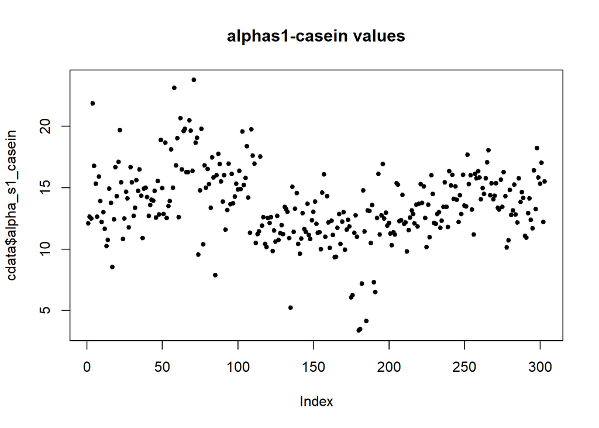

```r
cdata <- cdata[-which(cdata[,9] > sd_up), ] #remove observations which are over 3 sds from eman
# plot alphas1-casein data without the removed values
plot(cdata$alpha_s1_casein, pch = 20, main = 'alphas1-casein values')
```

## Question 3

Use hierarchical clustering and k-means clustering to determine if there are clusters of similar MIR spectra in the data. Motivate any decisions you make. Compare the hierarchical clustering and k-means clustering solutions. Comment on/explore any clustering structure you uncover, considering the data-generating context.

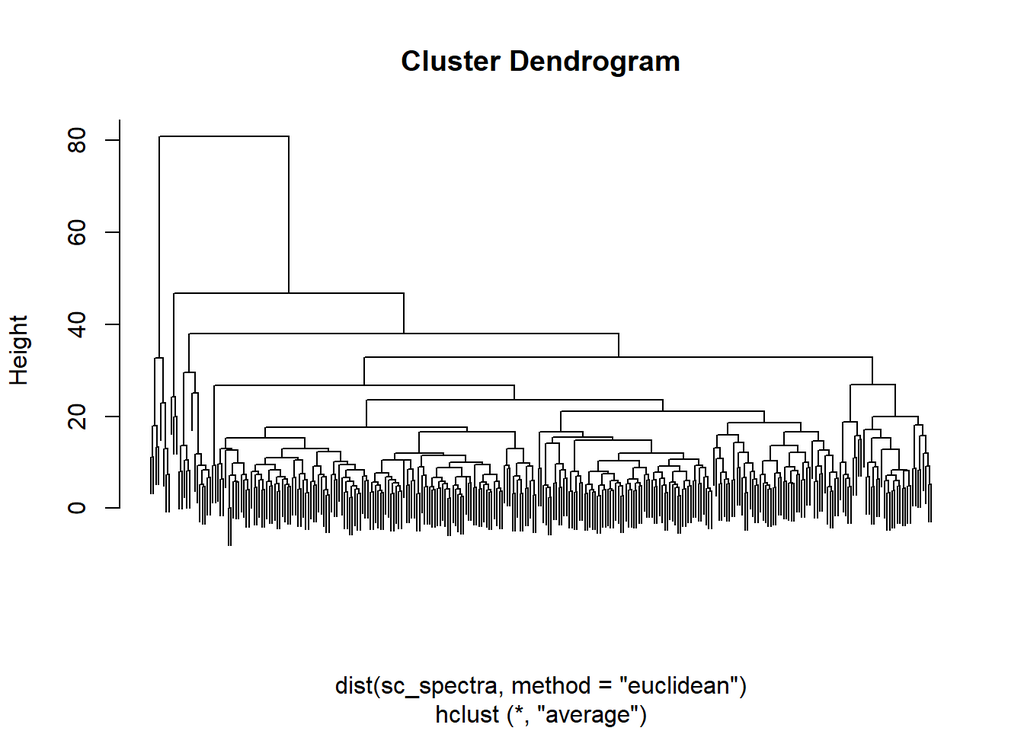

```r
spectra <- as.matrix(cdata[,52:582])
sc_spectra <- scale(spectra)

# Hierarchical Clustering
# compare average linkage & complete linkage solutions
cl.average = hclust(dist(sc_spectra, method = 'euclidean'), method="average")
plot(cl.average, labels = FALSE) # Looks to be roughly 6 clusters
```

```r
hcl.average = cutree(cl.average, k = 6)
table(hcl.average) # average linkage creates 2 large clusters as well as many smaller clusters
```

```
## hcl.average
##   1   2   3   4   5   6
## 243  36  13   4   3   4
```

Based on the above dendrogram I decided on a 6-cluster solution for average-linkage, as this seemed to provide a decent set of clusters, while also keeping the number of clusters relatively low for ease of interpretation of our results. We see from the table of clusters, that this approach resulted in one very large cluster, followed by a number of much smaller clusters. The following plots examine this clustering solution against various metrics of interest, the means of the spectral data & the standard deviations of the spectral data.

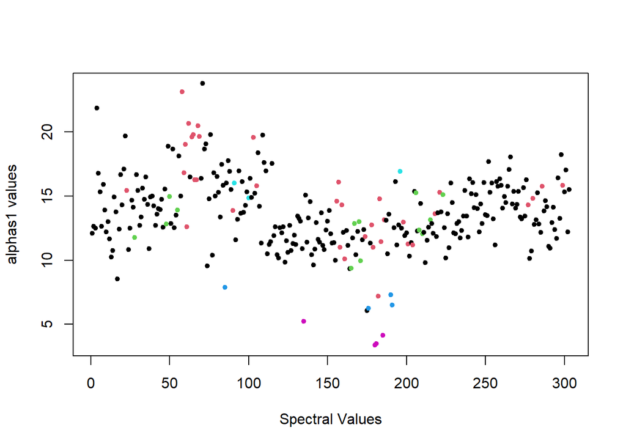

```r
plot(cdata[,9], col = hcl.average, pch = 20,
     xlab = 'Spectral Values', ylab = 'alphas1 values')
```

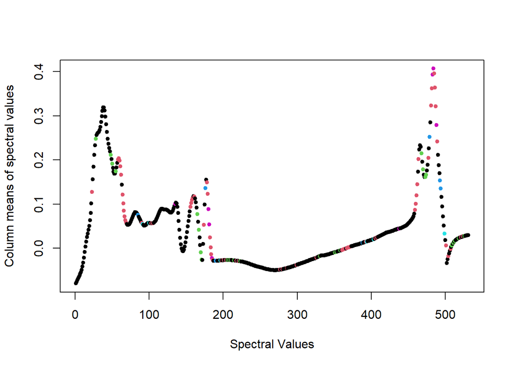

```r
plot(colMeans(spectra), col = hcl.average, pch = 20,
     xlab = 'Spectral Values', ylab = 'Column means of spectral values')
```

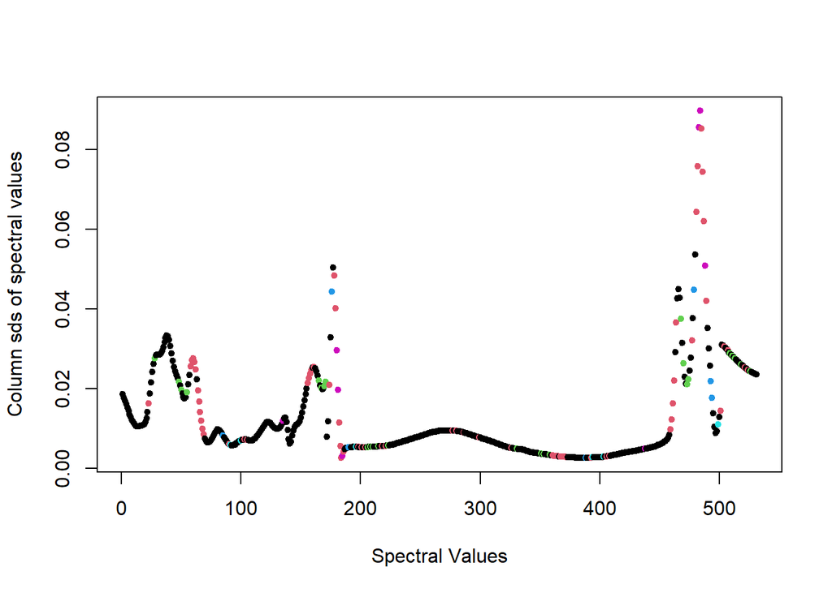

```r
plot(apply(spectra, 2, sd), col = hcl.average, pch = 20,
     xlab = 'Spectral Values', ylab = 'Column sds of spectral values')
```

```r
# average linkage gives us one very big cluster with lots of smaller ones which is not ideal
```

Overall, based on the above information, I do not feel that the average-linkage approach has provided a particularly good clustering solution, as it is not really apparent from any of the plots that the observations within each cluster behave in similar ways. The solution seems to have mostly classed the observations with particularly high standard deviation on the left-hand side of the plot of spectral values vs standard deviations within the same cluster, but overall, it does not appear that the observations in each cluster are particularly similar, and more importantly there is not much evidence that the observations in different clusters are very dissimilar. In addition to this, the fact that the solution puts so many of the observations in one cluster, and so few in each of the other clusters is a cause of concern.

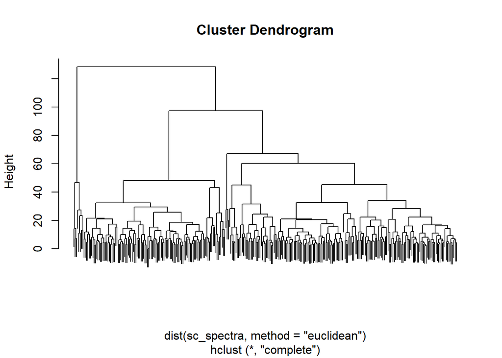

```r
cl.complete = hclust(dist(sc_spectra, method = 'euclidean'), method="complete")
plot(cl.complete, labels = FALSE)
```

```r
# dendrogram for complete linkage looks much better
hcl.complete = cutree(cl.complete, k = 5) # seems to roughly  main clusters in data
table(hcl.complete)
```

```
## hcl.complete
##   1   2   3   4   5
## 142  38 112   8   3
```

For the complete-linkage solution, we obtain a solution which certainly seems a lot less “stringy” than the average-linkage approach, with a lot more even a distribution of observations between each cluster. Based on the above dendrogram, I decided to cut the tree into 5 separate clusters. The complete-linkage approach provides two large clusters of roughly equal size, one medium sized cluster, as well as 2 smaller clusters. Again, we examine the clustering solution against the same metrics of interest we compared the average linkage solution.

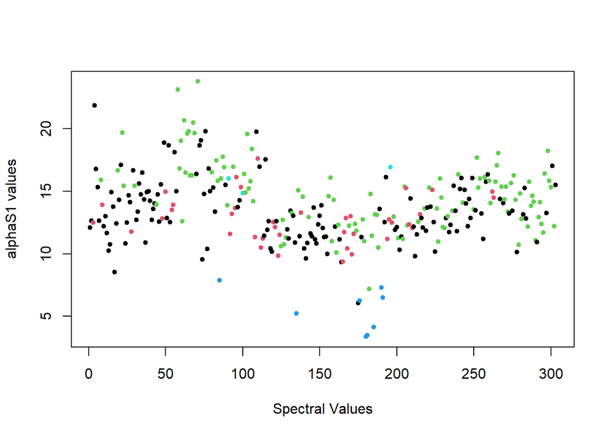

```r
plot(cdata[,9], col = hcl.complete, pch = 20,
     xlab = 'Spectral Values', ylab = 'alphaS1 values')
```

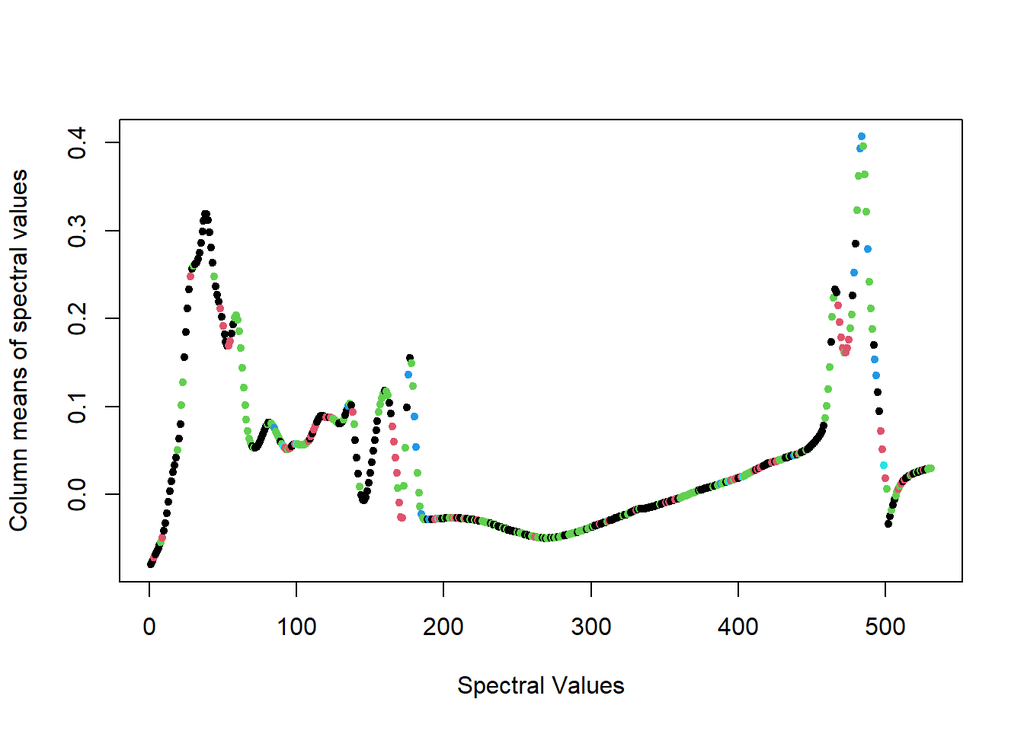

```r
plot(colMeans(spectra), col = hcl.complete, pch = 20,
     xlab = 'Spectral Values', ylab = 'Column means of spectral values')
```

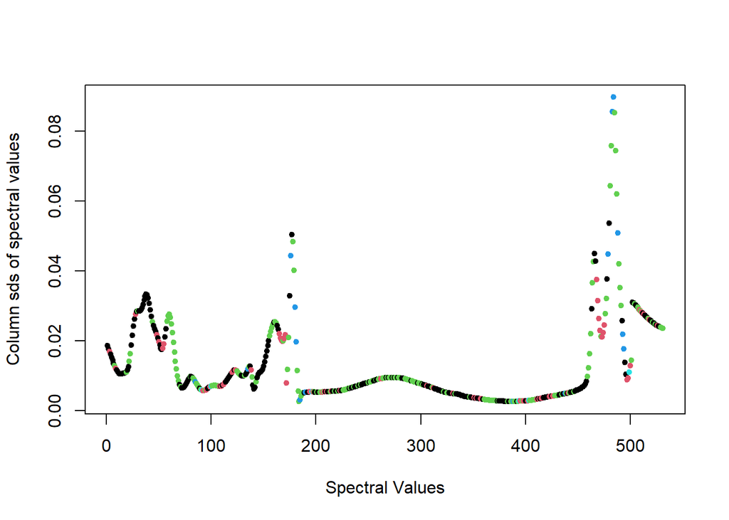

```r
plot(apply(spectra, 2, sd), col = hcl.complete, pch = 20,
     xlab = 'Spectral Values', ylab = 'Column sds of spectral values')
```

Once again, the clustering pattern is not particularly apparent within any of the plots, though the solution does seem to have grouped together most of the MIR spectra with particularly high mean & standard deviation into the same clusters, but it is quite difficult to tell if the solution is classing the other MIR spectral in groups which are highly dissimilar.

```r
table(hcl.average, hcl.complete)# clustering methods seem to be giving similar solutions
```

```
##            hcl.complete
## hcl.average   1   2   3   4   5
##           1 142  25  76   0   0
##           2   0   0  36   0   0
##           3   0  13   0   0   0
##           4   0   0   0   4   0
##           5   0   0   0   0   3
##           6   0   0   0   4   0
```

```r
classAgreement(table(hcl.average, hcl.complete))
```

```
## $diag
## [1] 0.4917492
##
## $kappa
## [1] 0.1428414
##
## $rand
## [1] 0.5777545
##
## $crand
## [1] 0.2194692
```

The adjusted Rand index measuring the strength of the class agreement between each of the 2 solutions is 21.95% indicating that while there is some agreement between them, the solutions do not agree particularly strongly when accounting for random chance.

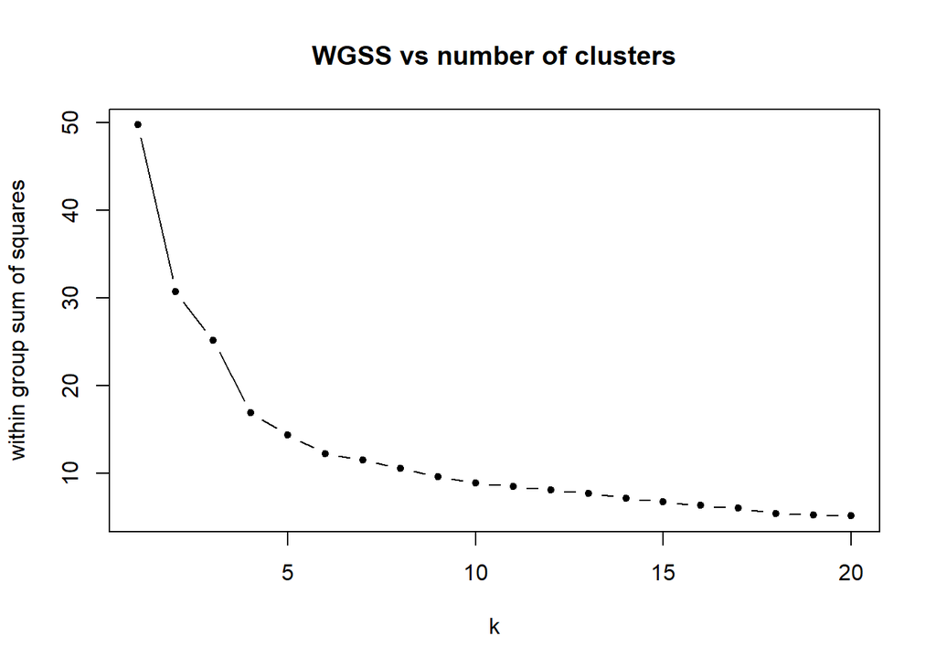

```r
WGSS = rep(0, 20)
n = nrow(sc_spectra)
WGSS[1] = (n-1)*sum(apply(spectra, 2, var))
for (k in 2:20) {
  WGSS[k] = sum(kmeans(spectra, centers = k)$withinss)
}
plot(1:20, WGSS, pch = 20, type = 'b', xlab = 'k', ylab = 'within group sum of squares',
     main = 'WGSS vs number of clusters')
```

```r
# Choosing k = 4 for our number of centres, seems optimal as it provides us with a low within group sum of squares without letting number of clusters grow too large
k = 4
cl.kmeans = kmeans(spectra, centers = k)
```

A 4-means clustering solution appears to be optimal from the above graph of the Within Group Sum of Squares as it appears at the elbow of the graph. This means that it provides a relatively low sum of squares, indicating that the observations within each group are quite similar, while also not including too many groups within our solution, which will aid interpretation.

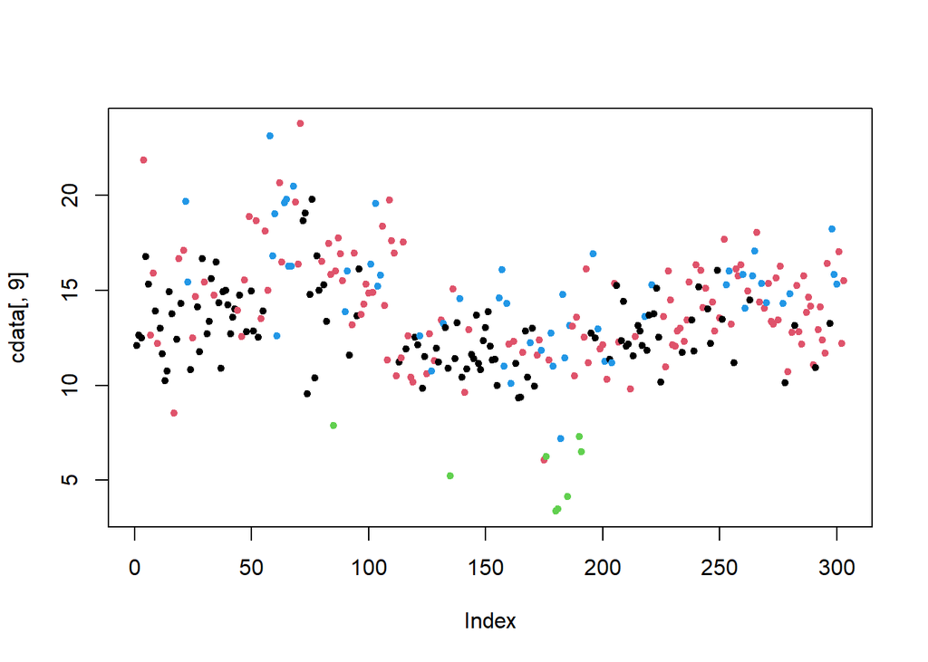

```r
plot(cdata[,9], pch = 20, col = cl.kmeans$cluster)
```

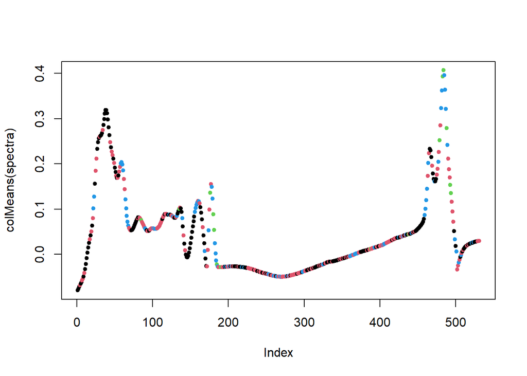

```r
plot(colMeans(spectra), pch = 20, col = cl.kmeans$cluster)
```

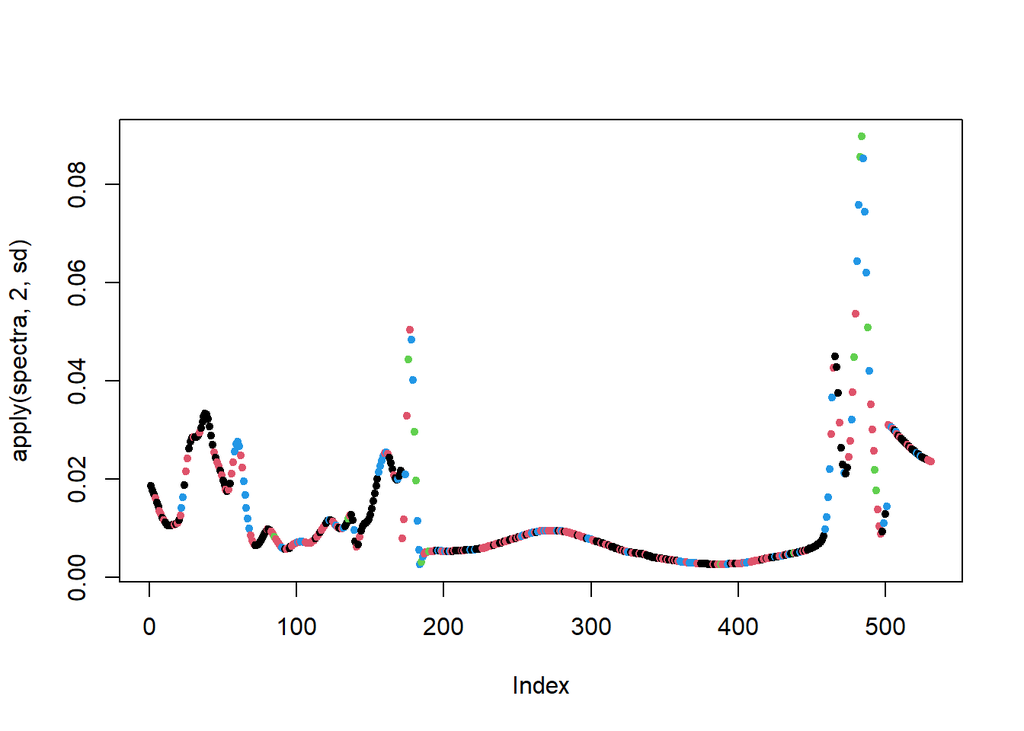

```r
plot(apply(spectra,2,sd), pch = 20, col = cl.kmeans$cluster)
```

Looking at the graphs, we observe a solution which seems to perform similarly to the hierarchical solutions calculated previously, with the solution seemingly classifying high mean/standard deviation MIR spectra relatively well, but with it not being particularly obvious that the classification is as successful for other ranges of MIR spectra.

```r
tab <- table(hcl.complete, cl.kmeans$cluster)
classAgreement(tab) # seems to be some agreement between solutions, but agreement not particularly strong
```

```
## $diag
## [1] 0.3168317
##
## $kappa
## [1] 0.09672077
##
## $rand
## [1] 0.6607873
##
## $crand
## [1] 0.2641719
```